# Project: Investigating TMBD dataset

- Introduction
- Data Wrangling
- Exploratory Data Analysis
- Conclusions

## Introduction

For this project, the TMBD dataset will be investigated. TMBD is a very famous website for movie revues and information, containing a multitude of data centered around the movies, who directed them, who starred in them, their genres, an overview of the movie, how much were these movies liked, how much they made, and how much was spent on them.

There are many questions that could be asked in this data-set and here are some examples I thought about

- Is budget related to revenue?
- Does employing multiple directors improve the quality of the movie?
- Which genres are more liked?
- Does the popularity of the imply a higher revenue?

The goal is to find answers to as many of these questions as possible. While The direct questions will be limited, their scope will try to encompass as much of these questions as possible

```python
# Use this cell to set up import statements for all of the packages that you
#   plan to use.

# Remember to include a 'magic word' so that your visualizations are plotted
#   inline with the notebook. See this page for more:
#   http://ipython.readthedocs.io/en/stable/interactive/magics.html

import pandas as pd
import matplotlib.pyplot as plt
import numpy as np
import seaborn as sns; sns.set()
import math
%matplotlib inline
```

## Data Wrangling

### General Properties

```python
# Load your data and print out a few lines. Perform operations to inspect data
#   types and look for instances of missing or possibly errant data.
movies = pd.read_csv("tmdb-movies.csv")
appointment = pd.read_csv("noshow-appointments.csv")
```

```python
movies.info()
```

```
<class 'pandas.core.frame.DataFrame'>
RangeIndex: 10866 entries, 0 to 10865
Data columns (total 21 columns):
id                      10866 non-null int64
imdb_id                 10856 non-null object
popularity              10866 non-null float64
budget                  10866 non-null int64
revenue                 10866 non-null int64
original_title          10866 non-null object
cast                    10790 non-null object
homepage                2936 non-null object
director                10822 non-null object
tagline                 8042 non-null object
keywords                9373 non-null object
overview                10862 non-null object
runtime                 10866 non-null int64
genres                  10843 non-null object
production_companies    9836 non-null object
release_date            10866 non-null object
vote_count              10866 non-null int64
vote_average            10866 non-null float64
release_year            10866 non-null int64
budget_adj              10866 non-null float64
revenue_adj             10866 non-null float64
dtypes: float64(4), int64(6), object(11)
memory usage: 1.7+ MB
```

```python
movies.describe()
```

|  | id | popularity | budget | revenue | runtime | vote_count | vote_average | release_year | budget_adj | revenue_adj |
| --- | --- | --- | --- | --- | --- | --- | --- | --- | --- | --- |
| count | 10866.000000 | 10866.000000 | 1.086600e+04 | 1.086600e+04 | 10866.000000 | 10866.000000 | 10866.000000 | 10866.000000 | 1.086600e+04 | 1.086600e+04 |
| mean | 66064.177434 | 0.646441 | 1.462570e+07 | 3.982332e+07 | 102.070863 | 217.389748 | 5.974922 | 2001.322658 | 1.755104e+07 | 5.136436e+07 |
| std | 92130.136561 | 1.000185 | 3.091321e+07 | 1.170035e+08 | 31.381405 | 575.619058 | 0.935142 | 12.812941 | 3.430616e+07 | 1.446325e+08 |
| min | 5.000000 | 0.000065 | 0.000000e+00 | 0.000000e+00 | 0.000000 | 10.000000 | 1.500000 | 1960.000000 | 0.000000e+00 | 0.000000e+00 |
| 25% | 10596.250000 | 0.207583 | 0.000000e+00 | 0.000000e+00 | 90.000000 | 17.000000 | 5.400000 | 1995.000000 | 0.000000e+00 | 0.000000e+00 |
| 50% | 20669.000000 | 0.383856 | 0.000000e+00 | 0.000000e+00 | 99.000000 | 38.000000 | 6.000000 | 2006.000000 | 0.000000e+00 | 0.000000e+00 |
| 75% | 75610.000000 | 0.713817 | 1.500000e+07 | 2.400000e+07 | 111.000000 | 145.750000 | 6.600000 | 2011.000000 | 2.085325e+07 | 3.369710e+07 |
| max | 417859.000000 | 32.985763 | 4.250000e+08 | 2.781506e+09 | 900.000000 | 9767.000000 | 9.200000 | 2015.000000 | 4.250000e+08 | 2.827124e+09 |

```python
movies.head(10)
```

|  | id | imdb_id | popularity | budget | revenue | original_title | cast | homepage | director | tagline | ... | overview | runtime | genres | production_companies | release_date | vote_count | vote_average | release_year | budget_adj | revenue_adj |
| --- | --- | --- | --- | --- | --- | --- | --- | --- | --- | --- | --- | --- | --- | --- | --- | --- | --- | --- | --- | --- | --- |
| 0 | 135397 | tt0369610 | 32.985763 | 150000000 | 1513528810 | Jurassic World | Chris Pratt\|Bryce Dallas Howard\|Irrfan Khan\|Vi... | http://www.jurassicworld.com/ | Colin Trevorrow | The park is open. | ... | Twenty-two years after the events of Jurassic ... | 124 | Action\|Adventure\|Science Fiction\|Thriller | Universal Studios\|Amblin Entertainment\|Legenda... | 6/9/15 | 5562 | 6.5 | 2015 | 1.379999e+08 | 1.392446e+09 |
| 1 | 76341 | tt1392190 | 28.419936 | 150000000 | 378436354 | Mad Max: Fury Road | Tom Hardy\|Charlize Theron\|Hugh Keays-Byrne\|Nic... | http://www.madmaxmovie.com/ | George Miller | What a Lovely Day. | ... | An apocalyptic story set in the furthest reach... | 120 | Action\|Adventure\|Science Fiction\|Thriller | Village Roadshow Pictures\|Kennedy Miller Produ... | 5/13/15 | 6185 | 7.1 | 2015 | 1.379999e+08 | 3.481613e+08 |
| 2 | 262500 | tt2908446 | 13.112507 | 110000000 | 295238201 | Insurgent | Shailene Woodley\|Theo James\|Kate Winslet\|Ansel... | http://www.thedivergentseries.movie/#insurgent | Robert Schwentke | One Choice Can Destroy You | ... | Beatrice Prior must confront her inner demons ... | 119 | Adventure\|Science Fiction\|Thriller | Summit Entertainment\|Mandeville Films\|Red Wago... | 3/18/15 | 2480 | 6.3 | 2015 | 1.012000e+08 | 2.716190e+08 |
| 3 | 140607 | tt2488496 | 11.173104 | 200000000 | 2068178225 | Star Wars: The Force Awakens | Harrison Ford\|Mark Hamill\|Carrie Fisher\|Adam D... | http://www.starwars.com/films/star-wars-episod... | J.J. Abrams | Every generation has a story. | ... | Thirty years after defeating the Galactic Empi... | 136 | Action\|Adventure\|Science Fiction\|Fantasy | Lucasfilm\|Truenorth Productions\|Bad Robot | 12/15/15 | 5292 | 7.5 | 2015 | 1.839999e+08 | 1.902723e+09 |
| 4 | 168259 | tt2820852 | 9.335014 | 190000000 | 1506249360 | Furious 7 | Vin Diesel\|Paul Walker\|Jason Statham\|Michelle ... | http://www.furious7.com/ | James Wan | Vengeance Hits Home | ... | Deckard Shaw seeks revenge against Dominic Tor... | 137 | Action\|Crime\|Thriller | Universal Pictures\|Original Film\|Media Rights ... | 4/1/15 | 2947 | 7.3 | 2015 | 1.747999e+08 | 1.385749e+09 |
| 5 | 281957 | tt1663202 | 9.110700 | 135000000 | 532950503 | The Revenant | Leonardo DiCaprio\|Tom Hardy\|Will Poulter\|Domhn... | http://www.foxmovies.com/movies/the-revenant | Alejandro González Iñárritu | (n. One who has returned, as if from the dead.) | ... | In the 1820s, a frontiersman, Hugh Glass, sets... | 156 | Western\|Drama\|Adventure\|Thriller | Regency Enterprises\|Appian Way\|CatchPlay\|Anony... | 12/25/15 | 3929 | 7.2 | 2015 | 1.241999e+08 | 4.903142e+08 |
| 6 | 87101 | tt1340138 | 8.654359 | 155000000 | 440603537 | Terminator Genisys | Arnold Schwarzenegger\|Jason Clarke\|Emilia Clar... | http://www.terminatormovie.com/ | Alan Taylor | Reset the future | ... | The year is 2029. John Connor, leader of the r... | 125 | Science Fiction\|Action\|Thriller\|Adventure | Paramount Pictures\|Skydance Productions | 6/23/15 | 2598 | 5.8 | 2015 | 1.425999e+08 | 4.053551e+08 |
| 7 | 286217 | tt3659388 | 7.667400 | 108000000 | 595380321 | The Martian | Matt Damon\|Jessica Chastain\|Kristen Wiig\|Jeff ... | http://www.foxmovies.com/movies/the-martian | Ridley Scott | Bring Him Home | ... | During a manned mission to Mars, Astronaut Mar... | 141 | Drama\|Adventure\|Science Fiction | Twentieth Century Fox Film Corporation\|Scott F... | 9/30/15 | 4572 | 7.6 | 2015 | 9.935996e+07 | 5.477497e+08 |
| 8 | 211672 | tt2293640 | 7.404165 | 74000000 | 1156730962 | Minions | Sandra Bullock\|Jon Hamm\|Michael Keaton\|Allison... | http://www.minionsmovie.com/ | Kyle Balda\|Pierre Coffin | Before Gru, they had a history of bad bosses | ... | Minions Stuart, Kevin and Bob are recruited by... | 91 | Family\|Animation\|Adventure\|Comedy | Universal Pictures\|Illumination Entertainment | 6/17/15 | 2893 | 6.5 | 2015 | 6.807997e+07 | 1.064192e+09 |
| 9 | 150540 | tt2096673 | 6.326804 | 175000000 | 853708609 | Inside Out | Amy Poehler\|Phyllis Smith\|Richard Kind\|Bill Ha... | http://movies.disney.com/inside-out | Pete Docter | Meet the little voices inside your head. | ... | Growing up can be a bumpy road, and it's no ex... | 94 | Comedy\|Animation\|Family | Walt Disney Pictures\|Pixar Animation Studios\|W... | 6/9/15 | 3935 | 8.0 | 2015 | 1.609999e+08 | 7.854116e+08 |

10 rows × 21 columns

### Data Cleaning

#### The following list represents the steps I have taken in cleaning the data

1. Removed some irrelavent or too incomplete features like
   - Homepage
   - Overview
   - Production Companies
   - Keywords
   - tagline
   - Cast
2. removed duplicates
3. seperate genres into different columns, renaming them with genres, put them in lower case and remove spaces to make them easier to follow
4. Fill empty directors with NA
5. Redefine Directors into Solos (S) and Cooperates (C)

```python
# After discussing the structure of the data and any problems that need to be
#   cleaned, perform those cleaning steps in the second part of this section.
movies = pd.read_csv("tmdb-movies.csv")
movies = movies.drop(columns=['homepage','overview','production_companies','tagline','keywords',"cast"])
movies = movies.drop_duplicates()
```

```python
genres = movies.genres.str.get_dummies()
genres = genres.rename(columns=lambda x: ((x+"_genre").replace(" ","_")).lower())
```

```python
movies = pd.concat([movies, genres], axis=1)
#movies = movies.append(cast) # Too much cast that my PC freezed while processing them
```

```python
movies.director.fillna("N", inplace=True)
```

```python
movies['director'] = np.where(movies['director'].str.find("|") != -1, "C", movies['director'])
movies['director'] = np.where(movies['director'] != "C" , "S", movies['director'])
```

```python
len(movies[movies['director'].str.find("|") != -1])
```

```
0
```

```python
movies.info()
```

```
<class 'pandas.core.frame.DataFrame'>
Int64Index: 10865 entries, 0 to 10865
Data columns (total 35 columns):
id                       10865 non-null int64
imdb_id                  10855 non-null object
popularity               10865 non-null float64
budget                   10865 non-null int64
revenue                  10865 non-null int64
original_title           10865 non-null object
director                 10865 non-null object
runtime                  10865 non-null int64
genres                   10842 non-null object
release_date             10865 non-null object
vote_count               10865 non-null int64
vote_average             10865 non-null float64
release_year             10865 non-null int64
budget_adj               10865 non-null float64
revenue_adj              10865 non-null float64
action_genre             10865 non-null int64
adventure_genre          10865 non-null int64
animation_genre          10865 non-null int64
comedy_genre             10865 non-null int64
crime_genre              10865 non-null int64
documentary_genre        10865 non-null int64
drama_genre              10865 non-null int64
family_genre             10865 non-null int64
fantasy_genre            10865 non-null int64
foreign_genre            10865 non-null int64
history_genre            10865 non-null int64
horror_genre             10865 non-null int64
music_genre              10865 non-null int64
mystery_genre            10865 non-null int64
romance_genre            10865 non-null int64
science_fiction_genre    10865 non-null int64
tv_movie_genre           10865 non-null int64
thriller_genre           10865 non-null int64
war_genre                10865 non-null int64
western_genre            10865 non-null int64
dtypes: float64(4), int64(26), object(5)
memory usage: 3.0+ MB
```

```python
popularity_outliers = movies.query("popularity>10")
unique_directors = movies.director.unique()
cooperating_directors = movies[movies['director'] == "C"]
solo_directors = movies[movies['director'] == "S"]
print("Number of probably outlier movies in popularity: "+ str(len(popularity_outliers)))
print("Number of unique directors: "+ str(len(unique_directors)))
print("Number of cooperating directors: "+ str(len(cooperating_directors)))
print("Number of single directors: "+ str(len(solo_directors)))
```

```
Number of probably outlier movies in popularity: 11
Number of unique directors: 2
Number of cooperating directors: 754
Number of single directors: 10111
```

```python
movies.describe()
```

|  | id | popularity | budget | revenue | runtime | vote_count | vote_average | release_year | budget_adj | revenue_adj | ... | history_genre | horror_genre | music_genre | mystery_genre | romance_genre | science_fiction_genre | tv_movie_genre | thriller_genre | war_genre | western_genre |
| --- | --- | --- | --- | --- | --- | --- | --- | --- | --- | --- | --- | --- | --- | --- | --- | --- | --- | --- | --- | --- | --- |
| count | 10865.000000 | 10865.000000 | 1.086500e+04 | 1.086500e+04 | 10865.000000 | 10865.000000 | 10865.000000 | 10865.000000 | 1.086500e+04 | 1.086500e+04 | ... | 10865.000000 | 10865.000000 | 10865.000000 | 10865.000000 | 10865.000000 | 10865.000000 | 10865.000000 | 10865.000000 | 10865.000000 | 10865.000000 |
| mean | 66066.374413 | 0.646446 | 1.462429e+07 | 3.982690e+07 | 102.071790 | 217.399632 | 5.975012 | 2001.321859 | 1.754989e+07 | 5.136900e+07 | ... | 0.030741 | 0.150667 | 0.037552 | 0.074551 | 0.157570 | 0.113116 | 0.015370 | 0.267556 | 0.024850 | 0.015186 |
| std | 92134.091971 | 1.000231 | 3.091428e+07 | 1.170083e+08 | 31.382701 | 575.644627 | 0.935138 | 12.813260 | 3.430753e+07 | 1.446383e+08 | ... | 0.172623 | 0.357741 | 0.190118 | 0.262678 | 0.364354 | 0.316749 | 0.123027 | 0.442705 | 0.155676 | 0.122299 |
| min | 5.000000 | 0.000065 | 0.000000e+00 | 0.000000e+00 | 0.000000 | 10.000000 | 1.500000 | 1960.000000 | 0.000000e+00 | 0.000000e+00 | ... | 0.000000 | 0.000000 | 0.000000 | 0.000000 | 0.000000 | 0.000000 | 0.000000 | 0.000000 | 0.000000 | 0.000000 |
| 25% | 10596.000000 | 0.207575 | 0.000000e+00 | 0.000000e+00 | 90.000000 | 17.000000 | 5.400000 | 1995.000000 | 0.000000e+00 | 0.000000e+00 | ... | 0.000000 | 0.000000 | 0.000000 | 0.000000 | 0.000000 | 0.000000 | 0.000000 | 0.000000 | 0.000000 | 0.000000 |
| 50% | 20662.000000 | 0.383831 | 0.000000e+00 | 0.000000e+00 | 99.000000 | 38.000000 | 6.000000 | 2006.000000 | 0.000000e+00 | 0.000000e+00 | ... | 0.000000 | 0.000000 | 0.000000 | 0.000000 | 0.000000 | 0.000000 | 0.000000 | 0.000000 | 0.000000 | 0.000000 |
| 75% | 75612.000000 | 0.713857 | 1.500000e+07 | 2.400000e+07 | 111.000000 | 146.000000 | 6.600000 | 2011.000000 | 2.085325e+07 | 3.370173e+07 | ... | 0.000000 | 0.000000 | 0.000000 | 0.000000 | 0.000000 | 0.000000 | 0.000000 | 1.000000 | 0.000000 | 0.000000 |
| max | 417859.000000 | 32.985763 | 4.250000e+08 | 2.781506e+09 | 900.000000 | 9767.000000 | 9.200000 | 2015.000000 | 4.250000e+08 | 2.827124e+09 | ... | 1.000000 | 1.000000 | 1.000000 | 1.000000 | 1.000000 | 1.000000 | 1.000000 | 1.000000 | 1.000000 | 1.000000 |

8 rows × 30 columns

```python
#print(movies.cast[9])
```

## Exploratory Data Analysis

### Research Question 1: How different are cooperating directors compared to solo directors?

Directors usually work solo as shown in the above cells, they outnumber directors work together by almost 10111 movie of an 10865 movie data set  
This trend is most likely based on the availability of directors to begin with, however does the hiring of multiple directors affect the quality of the movie at all?  
Usually the quality in this case is measured by how popular or high earning they are  
So in this section we will how the few movies that had multiple directors performed have improved or otherwise, looking at the popularity score, revenue and votes  
There is also a small pattern study, as whether the runtime of a movie affects the quality, and how high of runtime either solo and non solo directors.

```python
# Use this, and more code cells, to explore your data. Don't forget to add
#   Markdown cells to document your observations and findings.

cooperating_directors = movies[movies['director'] == "C"]
solo_directors = movies[movies['director'] == "S"]
```

```python
cooperating_directors.describe()
```

|  | id | popularity | budget | revenue | runtime | vote_count | vote_average | release_year | budget_adj | revenue_adj | ... | history_genre | horror_genre | music_genre | mystery_genre | romance_genre | science_fiction_genre | tv_movie_genre | thriller_genre | war_genre | western_genre |
| --- | --- | --- | --- | --- | --- | --- | --- | --- | --- | --- | --- | --- | --- | --- | --- | --- | --- | --- | --- | --- | --- |
| count | 754.000000 | 754.000000 | 7.540000e+02 | 7.540000e+02 | 754.000000 | 754.000000 | 754.000000 | 754.000000 | 7.540000e+02 | 7.540000e+02 | ... | 754.000000 | 754.000000 | 754.000000 | 754.000000 | 754.000000 | 754.000000 | 754.000000 | 754.000000 | 754.000000 | 754.000000 |
| mean | 83176.218833 | 0.727287 | 1.626944e+07 | 5.338909e+07 | 95.484085 | 274.652520 | 6.137268 | 2004.391247 | 1.909188e+07 | 6.375677e+07 | ... | 0.023873 | 0.145889 | 0.054377 | 0.033156 | 0.086207 | 0.122016 | 0.009284 | 0.145889 | 0.022546 | 0.006631 |
| std | 100666.723383 | 1.147845 | 3.606700e+07 | 1.498130e+08 | 55.835824 | 661.539894 | 0.977042 | 11.518078 | 4.026323e+07 | 1.730364e+08 | ... | 0.152754 | 0.353229 | 0.226910 | 0.179164 | 0.280856 | 0.327521 | 0.095968 | 0.353229 | 0.148551 | 0.081216 |
| min | 5.000000 | 0.001117 | 0.000000e+00 | 0.000000e+00 | 0.000000 | 10.000000 | 3.000000 | 1961.000000 | 0.000000e+00 | 0.000000e+00 | ... | 0.000000 | 0.000000 | 0.000000 | 0.000000 | 0.000000 | 0.000000 | 0.000000 | 0.000000 | 0.000000 | 0.000000 |
| 25% | 13201.000000 | 0.187466 | 0.000000e+00 | 0.000000e+00 | 84.000000 | 16.000000 | 5.600000 | 2001.000000 | 0.000000e+00 | 0.000000e+00 | ... | 0.000000 | 0.000000 | 0.000000 | 0.000000 | 0.000000 | 0.000000 | 0.000000 | 0.000000 | 0.000000 | 0.000000 |
| 50% | 31957.000000 | 0.360581 | 0.000000e+00 | 0.000000e+00 | 92.000000 | 38.000000 | 6.200000 | 2008.000000 | 0.000000e+00 | 0.000000e+00 | ... | 0.000000 | 0.000000 | 0.000000 | 0.000000 | 0.000000 | 0.000000 | 0.000000 | 0.000000 | 0.000000 | 0.000000 |
| 75% | 109962.250000 | 0.780414 | 1.200000e+07 | 1.669242e+07 | 101.000000 | 165.500000 | 6.900000 | 2012.000000 | 1.523245e+07 | 2.138013e+07 | ... | 0.000000 | 0.000000 | 0.000000 | 0.000000 | 0.000000 | 0.000000 | 0.000000 | 0.000000 | 0.000000 | 0.000000 |
| max | 386501.000000 | 12.971027 | 2.600000e+08 | 1.274219e+09 | 877.000000 | 6351.000000 | 8.500000 | 2015.000000 | 2.600000e+08 | 1.574815e+09 | ... | 1.000000 | 1.000000 | 1.000000 | 1.000000 | 1.000000 | 1.000000 | 1.000000 | 1.000000 | 1.000000 | 1.000000 |

8 rows × 30 columns

```python
solo_directors.describe()
```

|  | id | popularity | budget | revenue | runtime | vote_count | vote_average | release_year | budget_adj | revenue_adj | ... | history_genre | horror_genre | music_genre | mystery_genre | romance_genre | science_fiction_genre | tv_movie_genre | thriller_genre | war_genre | western_genre |
| --- | --- | --- | --- | --- | --- | --- | --- | --- | --- | --- | --- | --- | --- | --- | --- | --- | --- | --- | --- | --- | --- |
| count | 10111.000000 | 10111.000000 | 1.011100e+04 | 1.011100e+04 | 10111.000000 | 10111.000000 | 10111.000000 | 10111.000000 | 1.011100e+04 | 1.011100e+04 | ... | 10111.000000 | 10111.000000 | 10111.000000 | 10111.000000 | 10111.000000 | 10111.000000 | 10111.000000 | 10111.000000 | 10111.000000 | 10111.000000 |
| mean | 64790.454851 | 0.640417 | 1.450160e+07 | 3.881553e+07 | 102.563050 | 213.130155 | 5.962912 | 2001.092968 | 1.743490e+07 | 5.044522e+07 | ... | 0.031253 | 0.151024 | 0.036297 | 0.077638 | 0.162892 | 0.112452 | 0.015824 | 0.276629 | 0.025022 | 0.015824 |
| std | 91342.987513 | 0.988140 | 3.049368e+07 | 1.141298e+08 | 28.681762 | 568.526059 | 0.930855 | 12.875869 | 3.382091e+07 | 1.422607e+08 | ... | 0.174010 | 0.358090 | 0.187038 | 0.267615 | 0.369285 | 0.315937 | 0.124802 | 0.447354 | 0.156200 | 0.124802 |
| min | 6.000000 | 0.000065 | 0.000000e+00 | 0.000000e+00 | 0.000000 | 10.000000 | 1.500000 | 1960.000000 | 0.000000e+00 | 0.000000e+00 | ... | 0.000000 | 0.000000 | 0.000000 | 0.000000 | 0.000000 | 0.000000 | 0.000000 | 0.000000 | 0.000000 | 0.000000 |
| 25% | 10495.500000 | 0.209067 | 0.000000e+00 | 0.000000e+00 | 90.000000 | 17.000000 | 5.400000 | 1994.000000 | 0.000000e+00 | 0.000000e+00 | ... | 0.000000 | 0.000000 | 0.000000 | 0.000000 | 0.000000 | 0.000000 | 0.000000 | 0.000000 | 0.000000 | 0.000000 |
| 50% | 20156.000000 | 0.385313 | 0.000000e+00 | 0.000000e+00 | 99.000000 | 38.000000 | 6.000000 | 2005.000000 | 0.000000e+00 | 0.000000e+00 | ... | 0.000000 | 0.000000 | 0.000000 | 0.000000 | 0.000000 | 0.000000 | 0.000000 | 0.000000 | 0.000000 | 0.000000 |
| 75% | 72373.000000 | 0.709870 | 1.600000e+07 | 2.417286e+07 | 112.000000 | 145.000000 | 6.600000 | 2011.000000 | 2.103337e+07 | 3.408467e+07 | ... | 0.000000 | 0.000000 | 0.000000 | 0.000000 | 0.000000 | 0.000000 | 0.000000 | 1.000000 | 0.000000 | 0.000000 |
| max | 417859.000000 | 32.985763 | 4.250000e+08 | 2.781506e+09 | 900.000000 | 9767.000000 | 9.200000 | 2015.000000 | 4.250000e+08 | 2.827124e+09 | ... | 1.000000 | 1.000000 | 1.000000 | 1.000000 | 1.000000 | 1.000000 | 1.000000 | 1.000000 | 1.000000 | 1.000000 |

8 rows × 30 columns

```python
solo_directors_deducted = solo_directors[cooperating_directors.revenue.min() < solo_directors.revenue]
```

```python
solo_directors_deducted = solo_directors_deducted[solo_directors_deducted.popularity > cooperating_directors.popularity.min()]
```

### Early observation

For Revenue wise however, the solo movies seem to be having far more earning, as Avatar is almost twice as much revenue as Frozen

After deducting the movies that had lesser revenue compared to the least successful cooperate movies (using the cells above), more that 5000 solo movies were ignored, this sub-sample will be used from now on

```python
combined_data =  pd.concat([solo_directors_deducted,cooperating_directors])
```

**Generally in the plots below, the solo directors seem to generally prefer having "more".**

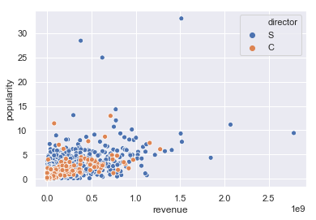

```python
ax = sns.scatterplot(x="revenue", y="popularity",hue="director", data=combined_data)
```

Most average solo directors have more freedom in their runtime, which is why many average solo movies have a longer runtime, there however seems to be no definite correlation between revenue and runtime.

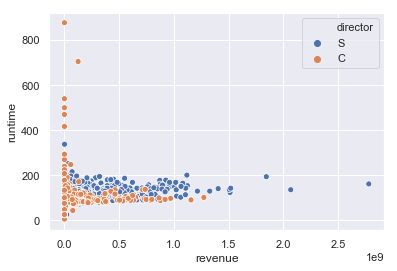

```python
ax = sns.scatterplot(x="revenue", y="runtime",hue="director", data=combined_data)
```

This plot does not add anything new to what was previously mentioned

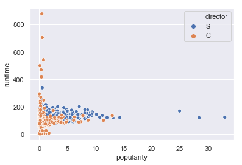

```python
ax = sns.scatterplot(x="popularity", y="runtime",hue="director", data=combined_data)
```

This does show that more solo movies get votes compared to cooporations, however no correlation here

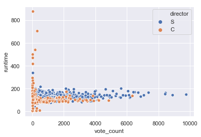

```python
ax = sns.scatterplot(x="vote_count", y="runtime",hue="director", data=combined_data)
```

This one shows a correlation between popularity and vote counts, which could mean that more people are more likely to vote on something if they like it. And it also shows that solo movies are both more popular and get more votes

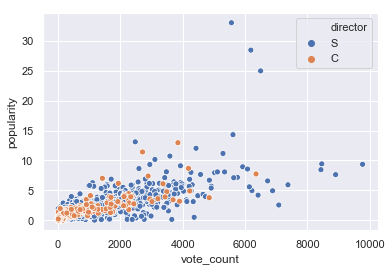

```python
ax = sns.scatterplot(x="vote_count", y="popularity",hue="director", data=combined_data)
```

This one furthermore confirms it, as apparently, if more people watch a movie and pay the ticket, they will also likely vote for it.

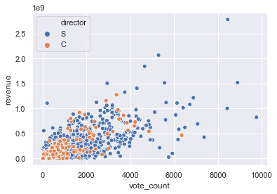

```python
ax = sns.scatterplot(x="vote_count", y="revenue",hue="director", data=combined_data)
```

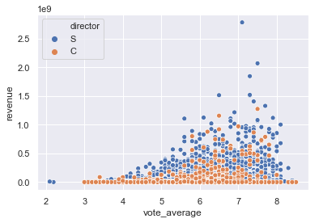

```python
ax = sns.scatterplot(x="vote_average", y="revenue",hue="director", data=combined_data)
```

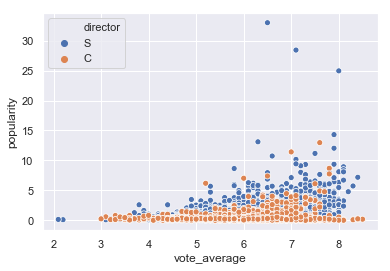

```python
ax = sns.scatterplot(x="vote_average", y="popularity",hue="director", data=combined_data)
```

### Research Question 2: Is genre related to popularity?

Multiple movies from different genres were made over the years, some were movies had several genres built into them, but which genres were conistently the more successful over the years? Also does popularity improve the revenue or not?

### The below charts are mostly incomprehensible since most genres overlap, we would need other charts

It is meant to show how much the movie changed popularity and revenue have change over the years, however all genres overlap and there are many movies, we could seperate them and analyse them individually. This may not be helpful either, we could try to remove all the lesser movies that earned too little to be considered influential, as many genres have their share of botched movies.

Popularity under 1 will be removed thereafter

**The following cells seperate all the genres into different part of the dictionary so they could be processed separetly**

```python
genres.columns
```

```
Index(['action_genre', 'adventure_genre', 'animation_genre', 'comedy_genre',
       'crime_genre', 'documentary_genre', 'drama_genre', 'family_genre',
       'fantasy_genre', 'foreign_genre', 'history_genre', 'horror_genre',
       'music_genre', 'mystery_genre', 'romance_genre',
       'science_fiction_genre', 'tv_movie_genre', 'thriller_genre',
       'war_genre', 'western_genre'],
      dtype='object')
```

```python
reducedMovies = movies[movies.popularity>1]
#reducedMovies = reducedMovies[reducedMovies.revenue>1000000]
reducedMovies.describe()
```

|  | id | popularity | budget | revenue | runtime | vote_count | vote_average | release_year | budget_adj | revenue_adj | ... | history_genre | horror_genre | music_genre | mystery_genre | romance_genre | science_fiction_genre | tv_movie_genre | thriller_genre | war_genre | western_genre |
| --- | --- | --- | --- | --- | --- | --- | --- | --- | --- | --- | --- | --- | --- | --- | --- | --- | --- | --- | --- | --- | --- |
| count | 1756.000000 | 1756.000000 | 1.756000e+03 | 1.756000e+03 | 1756.000000 | 1756.000000 | 1756.000000 | 1756.000000 | 1.756000e+03 | 1.756000e+03 | ... | 1756.000000 | 1756.000000 | 1756.000000 | 1756.00000 | 1756.000000 | 1756.000000 | 1756.000000 | 1756.000000 | 1756.000000 | 1756.000000 |
| mean | 58178.353645 | 2.101489 | 5.103648e+07 | 1.797760e+08 | 110.608200 | 979.667995 | 6.387358 | 2003.872437 | 5.748676e+07 | 2.201003e+08 | ... | 0.023918 | 0.092255 | 0.023918 | 0.08656 | 0.152620 | 0.173121 | 0.001139 | 0.311503 | 0.031321 | 0.011959 |
| std | 87624.072436 | 1.836949 | 5.256041e+07 | 2.299267e+08 | 22.872874 | 1115.521459 | 0.783752 | 10.850642 | 5.452117e+07 | 2.799882e+08 | ... | 0.152837 | 0.289468 | 0.152837 | 0.28127 | 0.359723 | 0.378459 | 0.033739 | 0.463240 | 0.174234 | 0.108732 |
| min | 5.000000 | 1.000194 | 0.000000e+00 | 0.000000e+00 | 0.000000 | 10.000000 | 3.300000 | 1960.000000 | 0.000000e+00 | 0.000000e+00 | ... | 0.000000 | 0.000000 | 0.000000 | 0.00000 | 0.000000 | 0.000000 | 0.000000 | 0.000000 | 0.000000 | 0.000000 |
| 25% | 2162.250000 | 1.207331 | 1.300000e+07 | 3.554476e+07 | 96.000000 | 304.000000 | 5.900000 | 1999.000000 | 1.655467e+07 | 4.233404e+07 | ... | 0.000000 | 0.000000 | 0.000000 | 0.00000 | 0.000000 | 0.000000 | 0.000000 | 0.000000 | 0.000000 | 0.000000 |
| 50% | 11004.500000 | 1.552851 | 3.400000e+07 | 1.092025e+08 | 108.000000 | 600.500000 | 6.400000 | 2007.000000 | 4.000231e+07 | 1.307588e+08 | ... | 0.000000 | 0.000000 | 0.000000 | 0.00000 | 0.000000 | 0.000000 | 0.000000 | 0.000000 | 0.000000 | 0.000000 |
| 75% | 73776.500000 | 2.294167 | 7.000000e+07 | 2.308670e+08 | 122.000000 | 1172.000000 | 6.900000 | 2012.000000 | 8.374146e+07 | 2.894069e+08 | ... | 0.000000 | 0.000000 | 0.000000 | 0.00000 | 0.000000 | 0.000000 | 0.000000 | 1.000000 | 0.000000 | 0.000000 |
| max | 417859.000000 | 32.985763 | 3.800000e+08 | 2.781506e+09 | 366.000000 | 9767.000000 | 8.400000 | 2015.000000 | 3.683713e+08 | 2.827124e+09 | ... | 1.000000 | 1.000000 | 1.000000 | 1.00000 | 1.000000 | 1.000000 | 1.000000 | 1.000000 | 1.000000 | 1.000000 |

8 rows × 30 columns

```python
genresDictionary = {}
for genre in genres.columns:
    genresDictionary[genre] = reducedMovies[reducedMovies[genre] == 1]
```

**The usage of the scatter plots in this context is practically useless as there are far genres to be visible, genres will have to studied as a group rather than individual movies**

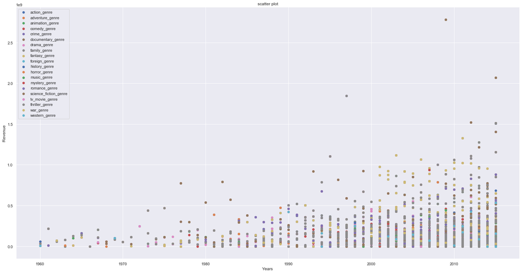

```python
# Continue to explore the data to address your additional research
#   questions. Add more headers as needed if you have more questions to
#   investigate
fig=plt.figure(figsize=(20,10))
ax=fig.add_axes([0,0,1,1])
np.random.seed(0)
for genre in genresDictionary:

    revenue = genresDictionary[genre].revenue
    time_range = genresDictionary[genre].release_year

    ax.scatter(time_range, revenue,label=genre)
    ax.set_xlabel('Years')
    ax.set_ylabel('Revenue')
    ax.set_title('scatter plot')
plt.legend(loc='best')
plt.show()
```

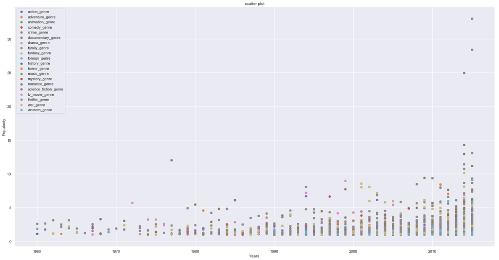

```python
fig=plt.figure(figsize=(20,10))
ax=fig.add_axes([0,0,1,1])
np.random.seed(0)
for genre in genresDictionary:

    popularity = genresDictionary[genre].popularity

    time_range = genresDictionary[genre].release_year

    ax.scatter(time_range, popularity,label=genre)
    ax.set_xlabel('Years')
    ax.set_ylabel('Popularity')
    ax.set_title('scatter plot')
plt.legend(loc='best')
plt.show()
```

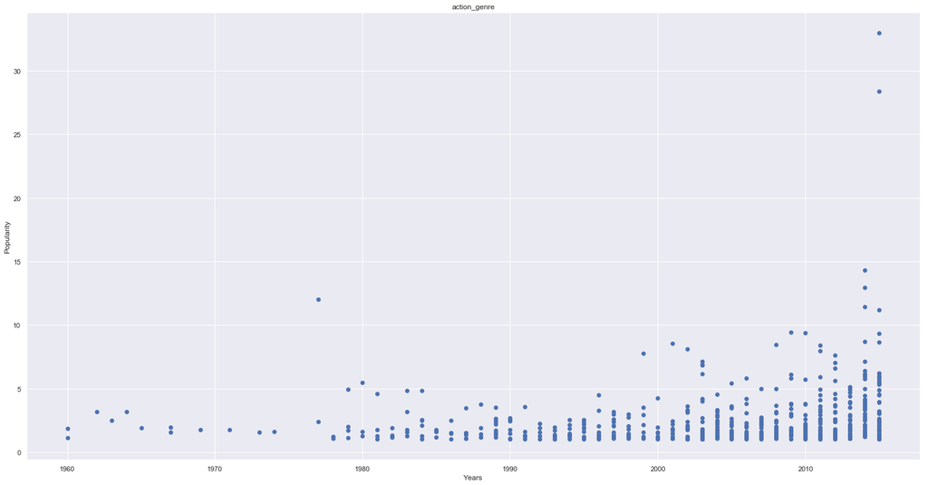

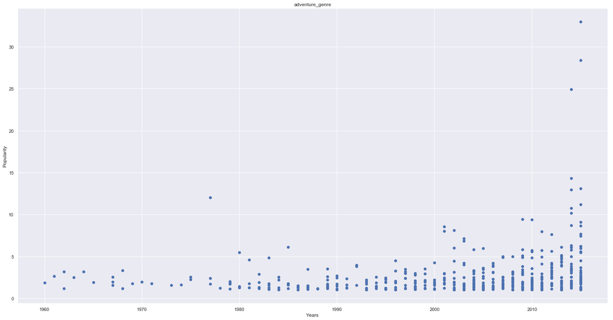

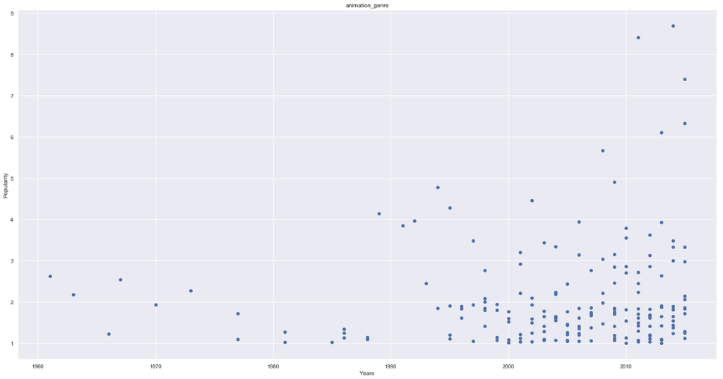

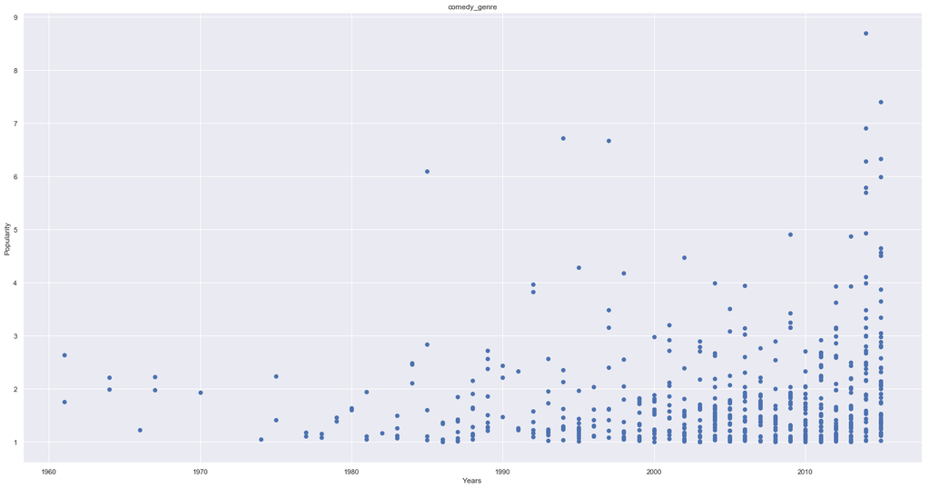

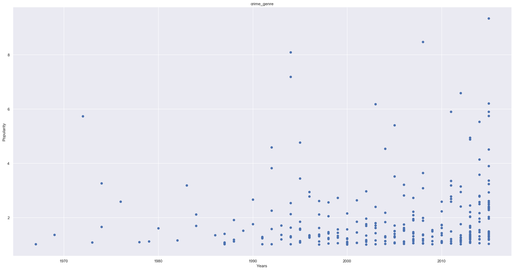

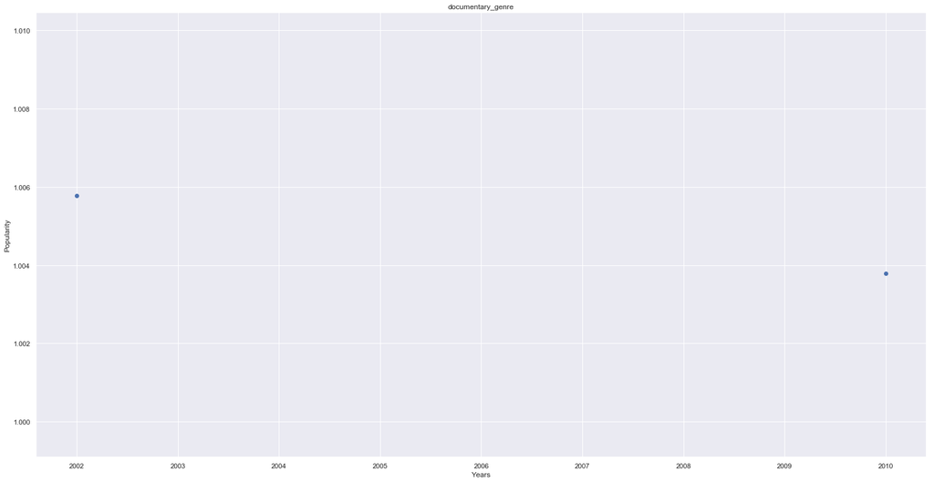

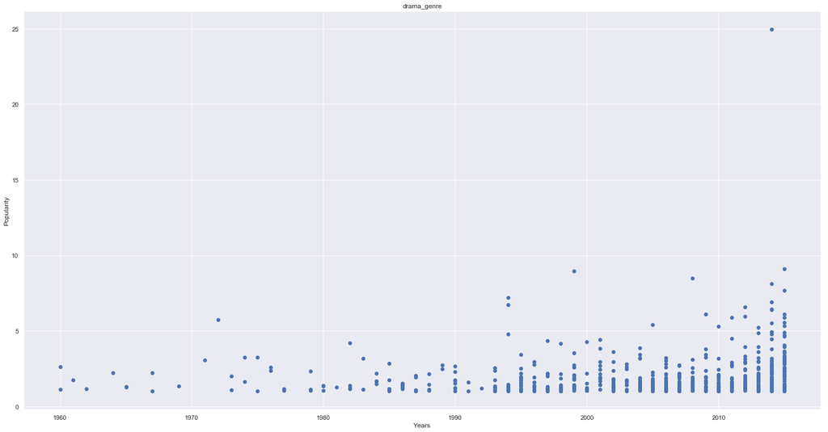

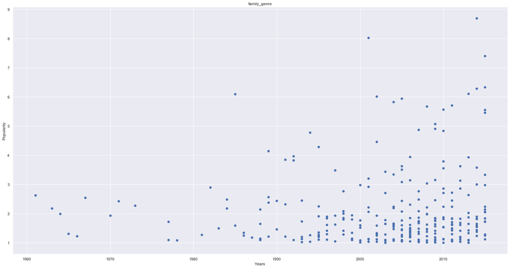

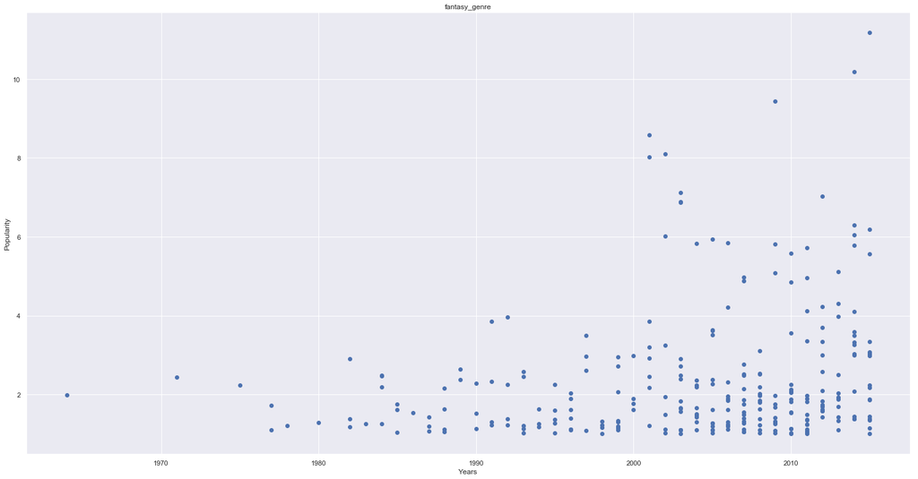

[figure not shown]

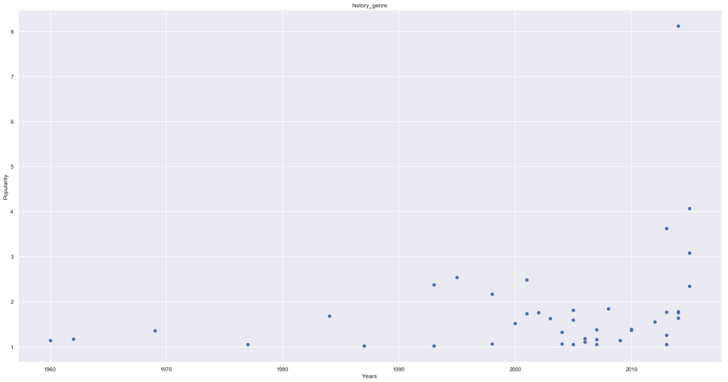

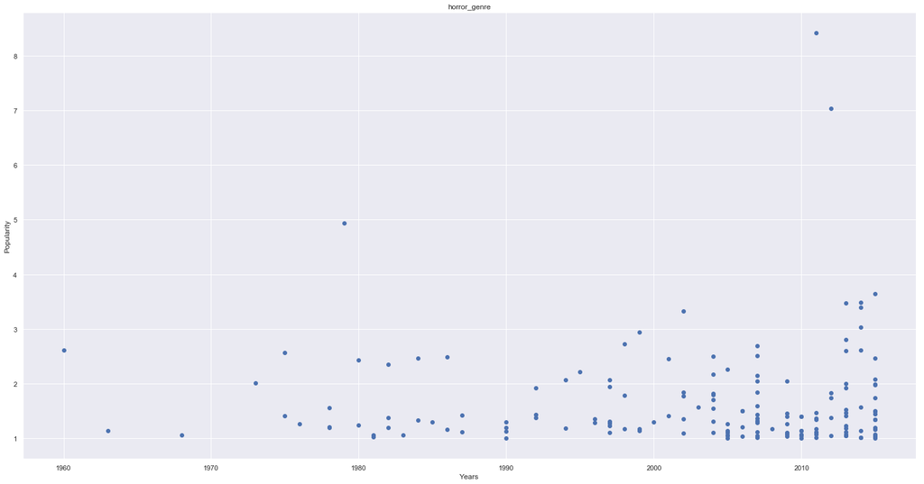

[8 more figures not shown]

```python
np.random.seed(0)
for genre in genresDictionary:
    fig=plt.figure(figsize=(20,10))
    ax=fig.add_axes([0,0,1,1])
    popularity = genresDictionary[genre].popularity
    time_range = genresDictionary[genre].release_year

    ax.scatter(time_range, popularity,label=genre)
    ax.set_xlabel('Years')
    ax.set_ylabel('Popularity')
    ax.set_title('scatter plot')
    plt.title(genre)
    plt.show()
```